# NBA jump shots: modeling and counterfactuals

James R Bland (https://sites.google.com/site/jamesbland/)

October 11, 2019

Recently, I had the pleasure of reading [Andrew Gelman’s blog post on golf putting](https://mc-stan.org/users/documentation/case-studies/golf.html), which got me thinking about whether one could take this model to data from other sports. Since late spring, I have been tinkering around with a [dataset of shots in the 2016-2017 NBA regular season](https://www.kaggle.com/wh0801/NBA-16-17-regular-season-shot-log/version/1), so this is where I started.

## The model

The simplest version of Andrew Gelman’s model assumes that a golf putt, or in my case, a jump shot, can be modeled as attempting to put a ball of radius $r$ across a circle of radius $R$.

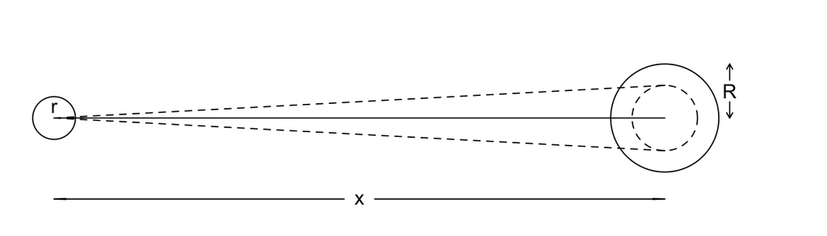

Source: https://mc-stan.org/users/documentation/case-studies/golf.html

The player attempts to aim directly at the circle, but is off by angle $\theta$, which is distributed $N(0,\sigma^2)$.

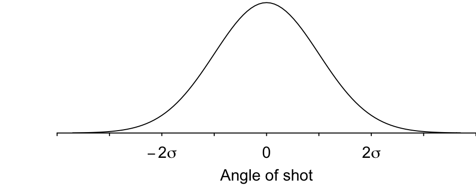

source: https://mc-stan.org/users/documentation/case-studies/golf.html

$\sigma$ is the standard deviation of this angle error. Dr. Gelman shows that the probability of making a putt (for me, hitting a jump shot), is equal to:
$$p_j=2\Phi\left(\frac{\sin^{-1}((R-r))/x_j}{\sigma}\right)-1$$
where $x_j$ is the distance to the hole (in my case, basket).

In this post, I use this model to assess the shot accuracy, measured by $\sigma$, of all players in the NBA who took more than 10 shots during the 2016-2017 regular season.

## Data

I use a [freely-available dataset of shots in the 2016-2017 NBA regular season](https://www.kaggle.com/wh0801/NBA-16-17-regular-season-shot-log/version/1). From here, I discard:

- all observations that do not have the string “Jump” in the shot description
- players who took fewer than 10 jump shots in this season (the model has a hard time with these), and
- all blocked shots.

This is what the data look like:

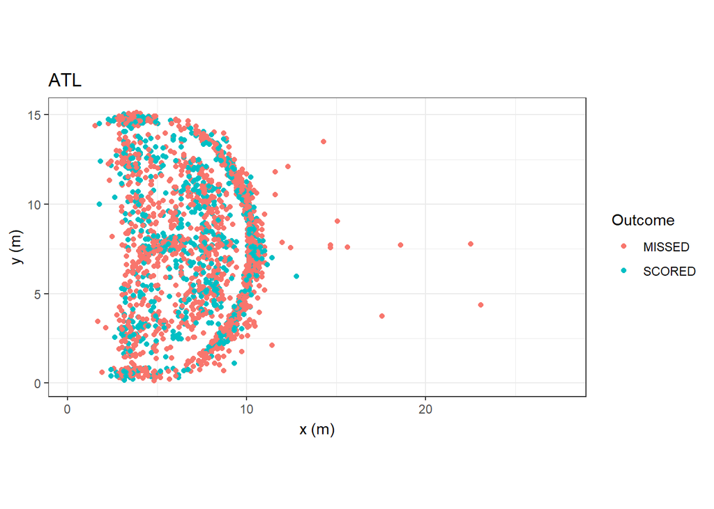

```r
plt<-ggplot(data=Data,aes(x=x,y=y,color=Outcome))+geom_point()
plt<-plt+transition_states(TeamName,transition_length=1,state_length=5)
plt<-plt+labs(title = '{closest_state}')+theme_bw()+ coord_fixed()
plt<-plt+xlab("x (m)")+ylab("y (m)")
plt
```

## Estimating the model in Stan

I run this Stan program on each player individually, and so have posterior simulations of each players’ $\sigma$:

```c
// NBAJumpShots.stan
functions {


}
data {
  // Tell Stan how to read in the data
  int NT; // Number of observations
  int y[NT]; // Shot success = 1
  vector[NT] x; // distance from basket
  real r;
  real R;

}
transformed data {
    vector[NT] threshold_angle = asin((R-r) ./ x);
}
parameters {
  real<lower=0,upper=pi()/2> sigma;

}
transformed parameters {

}
model {
    vector[NT] p = 2*Phi(threshold_angle / sigma) - 1;

  sigma ~ normal(0,pi()/6);
  y ~ bernoulli(p);


  }
generated quantities {
  real sigma_degrees = sigma * 180 / pi();
}
```

This is the same as Andrew Gelman’s file, except that my prior for $\sigma$ is $N(0,\pi/6)$, truncated to $(0,\pi/2)$. As there are quite a few players who do not take many shots, the prior is much more important for pinning down $\sigma$ for these people.

## Results

Here is the histogram of the estimates of each player’s $\sigma$

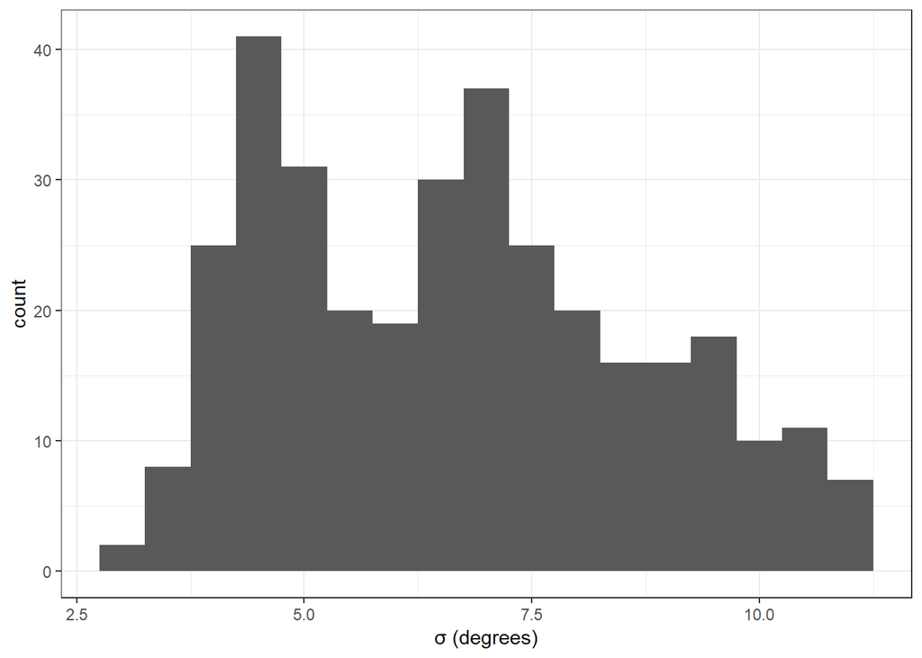

```r
Means<-aggregate(SimResults[,1:2],by=list(SimResults$Player),FUN=mean)
Means<-Means[,c(1,2,3)]
colnames(Means)<-c("Player","sigma","sigma_degrees")

plt<-ggplot(data=Means[Means$sigma_degrees<11 & is.na(Means$sigma)==FALSE,],aes(x=sigma_degrees))+geom_histogram(binwidth=0.5)
plt<-plt+theme_bw()+xlab("\U03C3 (degrees)")
plt
```

However, it may be a bit more meaningful to display this as the (estimated) probability of hitting a 3-point shot, standing on the 3-point line directly in front of the basket:

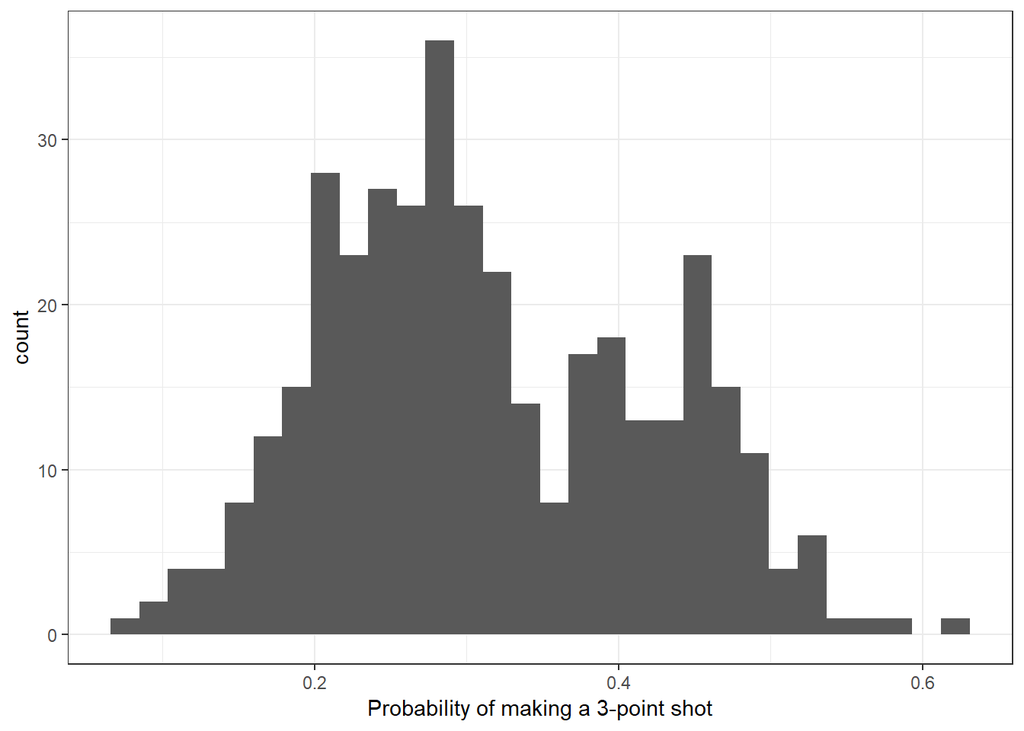

```r
prb3<-aggregate(2*pnorm(asin((0.450-4.7*2.54/100)/7.24)/SimResults$sigma)-1,by=list(SimResults$Player),FUN=mean)

plt<-ggplot(data=prb3[is.na(prb3$x)==FALSE,],aes(x=x))+geom_histogram(bins=30)
plt<-plt+theme_bw()+xlab("Probability of making a 3-point shot")
plt
```

It may also be interesting to compare these estimates (i.e. difficulty-adjusted scoring probabilities) to players’ raw scoring probabilities:

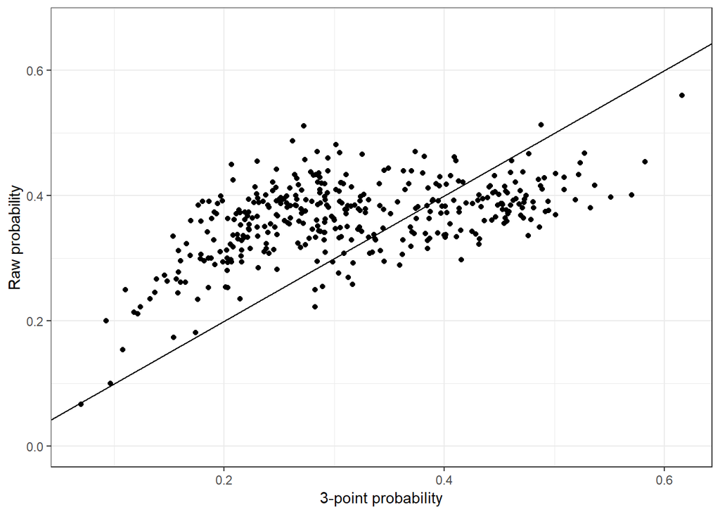

```r
mScored<-data.frame(aggregate(Data$Scored,by=list(Data$ShootPlayer),FUN=mean))
d<-merge(mScored,prb3,by.x="Group.1",by.y="Group.1")
colnames(d)<-c("Player","prbRaw","prb3")

plt<-ggplot(data=d,aes(y=prbRaw,x=prb3))+geom_point()
plt<-plt+ylab("Raw probability")+xlab("3-point probability")
plt<-plt+theme_bw()+geom_abline(intercept=0,slope=1)
plt
```

That is, the horizontal coordinate of each point is a player’s estimated probability, when shooting from exactly the same spot. Players with points above the $45^\circ$ line are scoring more frequently than the 3-point probability would suggest, meaning that they are taking easier shots.

Who are these people?

```r
ShowThis<-d[order(d$prbRaw/d$prb3,decreasing = TRUE),]
ShowThis[1:20,]
```

```
##                Player    prbRaw       prb3
## 76       Cole Aldrich 0.2500000 0.11031265
## 148   Hollis Thompson 0.3356643 0.15373873
## 119          Ed Davis 0.3846154 0.17631793
## 382    Tim Quarterman 0.4500000 0.20640122
## 294  Montrezl Harrell 0.3906250 0.18028457
## 74       Clint Capela 0.2000000 0.09267344
## 13     Alex Poythress 0.3600000 0.16962946
## 385      TJ McConnell 0.3911565 0.18625903
## 8        Al Jefferson 0.4247104 0.20786530
## 129       Evan Turner 0.3994911 0.19709362
## 355  Sergio Rodriguez 0.3592677 0.17886053
## 360        Shawn Long 0.3870968 0.19374223
## 313   Pat Connaughton 0.4545455 0.23015078
## 161     Jahlil Okafor 0.3915344 0.19834550
## 377   Thomas Robinson 0.3125000 0.15842253
## 334    Richaun Holmes 0.3736264 0.19086520
## 87        Dario Saric 0.3235294 0.16578139
## 303      Nik Stauskas 0.3632287 0.18867423
## 41    Bismack Biyombo 0.3714286 0.19301259
## 366 Stephen Zimmerman 0.2666667 0.13863636
```

Also, while we’re here, here are the most accurate players based on $\sigma$:

```r
ShowThis<-d[order(d$prb3,decreasing = TRUE),]
ShowThis[1:20,]
```

```
##               Player    prbRaw      prb3
## 391   Treveon Graham 0.5600000 0.6158896
## 356       Seth Curry 0.4538879 0.5823496
## 409  Wayne Ellington 0.4007707 0.5702866
## 30  Anthony Tolliver 0.3977695 0.5510718
## 255     Luke Babbitt 0.4166667 0.5367507
## 11      Alex Abrines 0.3809524 0.5329976
## 344      Roy Hibbert 0.4680851 0.5271693
## 40        Beno Udrih 0.4520548 0.5234716
## 34     Arron Afflalo 0.4338462 0.5218225
## 264  Marco Belinelli 0.3937008 0.5191943
## 185       Jeremy Lin 0.4094203 0.5090321
## 108    Dirk Nowitzki 0.4293103 0.5087948
## 78      Courtney Lee 0.4350877 0.5012815
## 202  Jonathan Gibson 0.3698630 0.5011409
## 131   Garrett Temple 0.3765432 0.4946530
## 107     Dion Waiters 0.3906634 0.4940771
## 46  Bojan Bogdanovic 0.3747610 0.4918952
## 31    Archie Goodwin 0.4285714 0.4911431
## 224     Kemba Walker 0.4107709 0.4889164
## 304     Nikola Jokic 0.5133820 0.4878019
```

## A counterfactual

Here are the model’s average (over all shots, and all simulation draws) shot probability as a function of distance from the basket:

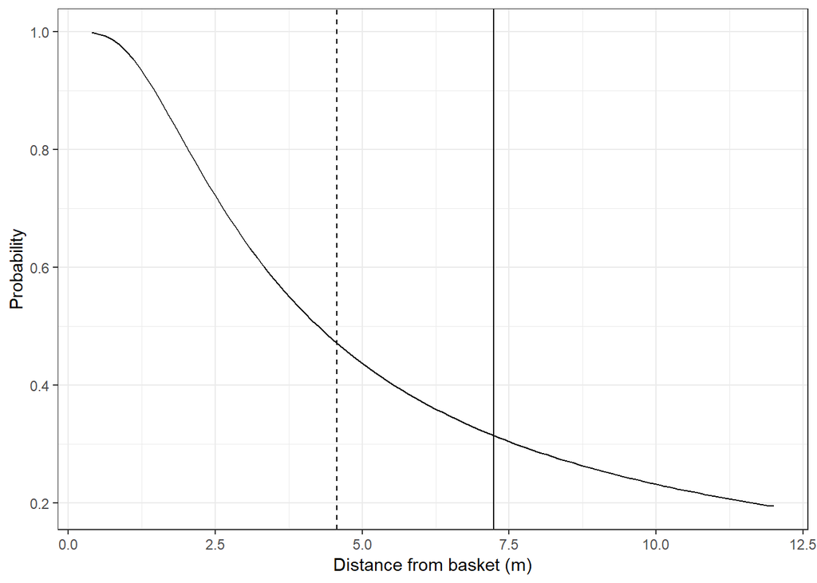

```r
L<-seq(0.4,12,length=100)

ShotProb<-data.frame()
sigmaSim<-SimResults$sigma
sigmaSim<-sigmaSim[is.na(sigmaSim)==FALSE]
for (ll in 1:length(L)) {

  pll<-2*pnorm(asin((0.450-4.7*2.54/100)/L[ll])/sigmaSim)-1
  simProbM<-mean(pll)
  d<-data.frame(simProbM)
  d$L<-L[ll]
  ShotProb<-rbind(ShotProb,d)
}

plt<-ggplot(data=ShotProb,aes(x=L,y=simProbM))+geom_line()
plt<-plt+theme_bw()
plt<-plt+geom_vline(xintercept=7.24)+geom_vline(xintercept=(5.79-1.22),linetype=2)
plt <-plt+xlab("Distance from basket (m)")+ylab("Probability")
plt
```

The vertical lines are placed at the foul line (4.57m) and 3-point line (7.24m). This implies an expected value of a shot taken from each distance. What if we moved the 3-point line a bit?

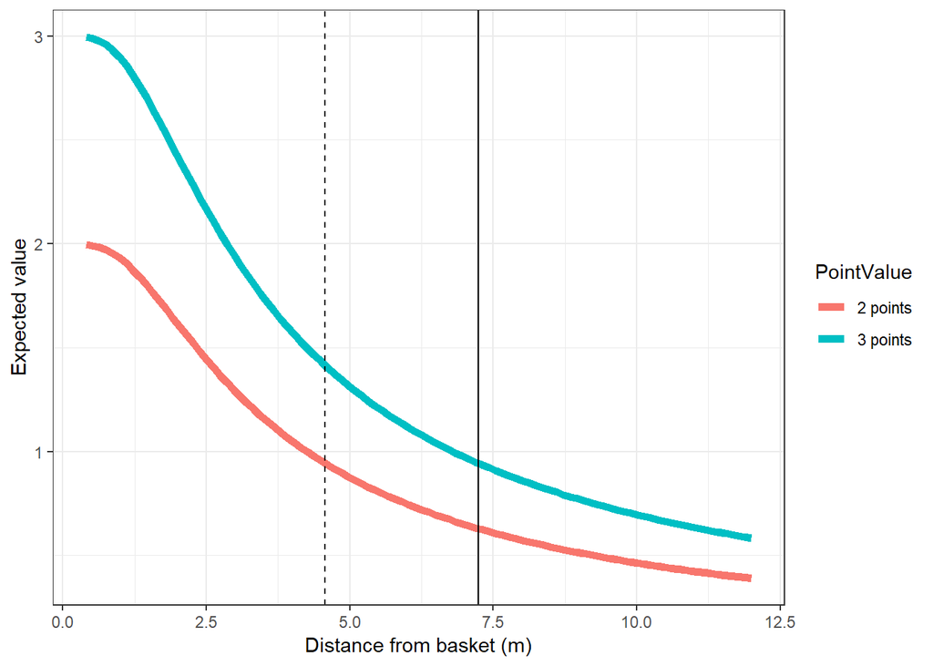

```r
EV<-data.frame()
v<-ShotProb$simProbM*2
v2<-data.frame(v,L)
v2$PointValue<-"2 points"
v<-ShotProb$simProbM*3
v3<-data.frame(v,L)
v3$PointValue<-"3 points"

EV<-rbind(v2,v3)

plt<-ggplot(data=EV,aes(x=L,y=v,color=PointValue,group=PointValue))+geom_line(size=2)
plt<-plt+theme_bw()
plt<-plt+geom_vline(xintercept=7.24)+geom_vline(xintercept=(5.79-1.22),linetype=2)
plt <-plt+xlab("Distance from basket (m)")+ylab("Expected value")
plt
```

Maybe moving the 3-point line out to about 8-10m would be enough to appreciably increase the fraction of shots taken from around the foul line.

[See more coding examples here](https://sites.google.com/site/jamesbland/code-examples)

## APPENDIX: Data wrangling and model estimation in R

```r
# NBAJumpShots.R
# data source: https://www.kaggle.com/wh0801/NBA-16-17-regular-season-shot-log/version/1

rm(list=ls())
setwd("C:/Users/jbland/OneDrive - University of Toledo/General notes on structural Bayes/Sports")
library(foreign)
library(xtable)
library(ggplot2)
library(gganimate)
library(gifski)
library(png)
library("rstan") # observe startup messages
rstan_options(auto_write = TRUE)
Sys.setenv(LOCAL_CPPFLAGS = '-march=native')
options(mc.cores = parallel::detectCores())



TeamList<-read.csv('NBA16-17/NBA team name vs abbreviation.csv')[,1]
Data<-data.frame()
for (tt in 1:length(TeamList)) {
  D<-read.csv(paste('NBA16-17/shot log ', TeamList[tt],'.csv',sep=""))

  colnames(D)<-c("SelfPrevious","PlayerPosition","Home","locationX","OpponentPrevious","HomeTeam","ShotType","points","AwayTeam","locationY","time","date","ShootPlayer","TimeFrom","quarter","Outcome")
  D$TeamName<-TeamList[tt]
  # only look at jump shots
  D<-D[grepl("Jump",D$ShotType),]
  # remove NAs
  D<-D[is.na(D$locationX)==FALSE,]
  D<-D[is.na(D$locationY)==FALSE,]

  D$x<- D$locationX
  D$y<- D$locationY
  DateList<-unique(D$date)
  for (dd in 1:length(DateList)) {
      d<-D[D$date==DateList[dd] & D$quarter==1,]
    dim(d)
    mx<-mean(d$locationX<500)
    if (mx>0.5) { # team is shooting to the left in 1st quarter
      D$x[D$date==DateList[dd] & D$quarter <3]<-1000-D$locationX
      D$y[D$date==DateList[dd] & D$quarter <3]<- 500-D$locationY
    }
    if (mx<=0.5) { # team is shooting to the right in 1st quarter
      D$x[D$date==DateList[dd] & D$quarter >=3]<-1000-D$locationX
      D$y[D$date==DateList[dd] & D$quarter >=3]<- 500-D$locationY
    }
  }

  D$x<-1000-D$x
  D$y<-500-D$y


  Data<-rbind(Data,D)
}





# Convert into meters
Data$locationX<-Data$locationX*28.7/1000
Data$locationX<-Data$locationY*15.2/500
# convert into SI units
Data$x<-Data$x*28.7/1000
Data$y<-Data$y*15.2/500

# distance to basket (m)
# ring is 1.22m from the baseline
Data$r<-sqrt((Data$x-1.22)^2+(Data$y-250*15.2/500)^2)

# Ignore overtime
Data<-Data[Data$quarter<=4,]

plt<-ggplot(data=Data,aes(x=x,y=y,color=Outcome))+geom_point()
plt<-plt+transition_states(TeamName,transition_length=1,state_length=5)
plt<-plt+labs(title = '{closest_state}')+theme_bw()+ coord_fixed()
anim_save(plt,filename = "NBAShotOutcomes.gif")

PlayerList<-unique(Data$ShootPlayer)

# Drop blocked shots
Data<-Data[Data$Outcome!="BLOCKED",]
Data$Scored<-as.integer(Data$Outcome=="SCORED")

r<-4.7*2.54/100 # radius of basketball in meters
R<-0.450 # radius of basketball in meters

Data$angle<-asin((R-r)/ Data$r)

Data<-Data[is.na(Data$angle)==FALSE,]


SimResults<-data.frame()

for (ii in 1:length(PlayerList)) {
  d<-Data[Data$ShootPlayer==PlayerList[ii],]

  StanData<-list(NT=dim(d)[1],y=d$Scored,x=d$r,r=r,R=R)
  if (StanData$NT>=10) { # only look at players who took at least 10 jump shots
  Sim<-stan("NBAJumpShots.stan",data=StanData)

  sigma_degrees<-extract(Sim)$sigma_degrees
  sigma<-extract(Sim)$sigma
  }
  else {
    sigma<-NA
    sigma_degrees<-NA
  }
  S<-data.frame(sigma,sigma_degrees)
  S$Player<-PlayerList[ii]
  S$Team<-d[1,"TeamName"]
  S$Position<-d[1,"PlayerPosition"]

  SimResults<-rbind(SimResults,S)

  print(paste(ii,"of",length(PlayerList),", N =",StanData$NT,", p =",mean(StanData$y)))

}

saveRDS(SimResults,"C:/Users/jbland/Documents/Sports/NBAJumpShots_SimIndividual.rds")
saveRDS(Data,"C:/Users/jbland/Documents/Sports/NBAJumpShots_CleanedData.rds")
```